# Delhi AQI Analysis

## **7. Log-Scaled Boxplot for Better Visualization**

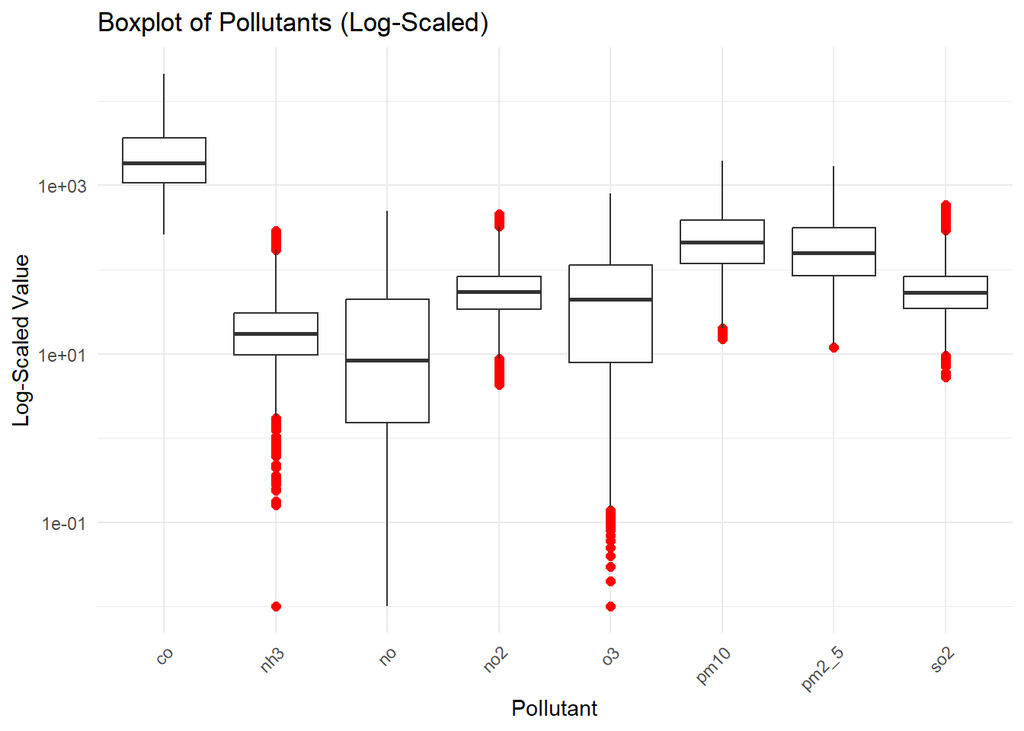

```r
data_aqi_long <- data_aqi %>%
  pivot_longer(cols = -date, names_to = "Pollutant", values_to = "Value")

ggplot(data_aqi_long, aes(x = Pollutant, y = Value)) +
  geom_boxplot(outlier.colour = "red", outlier.shape = 16, outlier.size = 2) +
  scale_y_log10() +
  theme_minimal() +
  labs(title = "Boxplot of Pollutants (Log-Scaled)", y = "Log-Scaled Value", x = "Pollutant") +
  theme(axis.text.x = element_text(angle = 45, hjust = 1))
```

## **8. PM2.5 Trend Over Time**

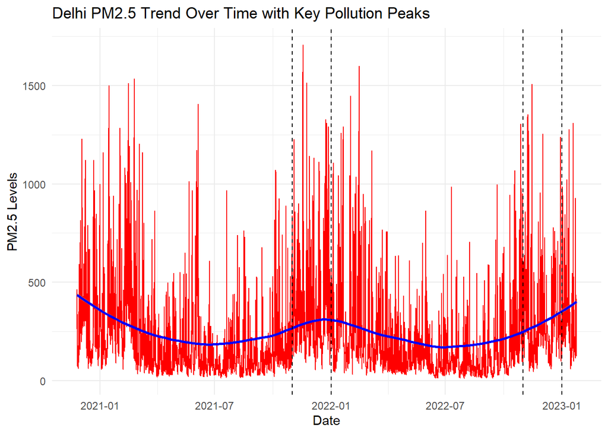

```r
data_aqi %>%
  ggplot(aes(x = date, y = pm2_5)) +
  geom_line(color = "red") +
  geom_smooth(method = "loess", color = "blue") +
  geom_vline(xintercept = as.Date(c("2021-11-01", "2022-01-01", "2022-11-01", "2023-01-01")),
             linetype = "dashed", color = "black") +
  labs(title = "Delhi PM2.5 Trend Over Time with Key Pollution Peaks",
       x = "Date", y = "PM2.5 Levels") +
  theme_minimal()
```

## **Interpretation of the PM2.5 Trend in Delhi**

### **1. Seasonal Variation**

- The **blue LOESS trend line** shows a **recurring U-shape pattern** every year.
- PM2.5 levels are **lowest in mid-year (June–July)** and **highest around November–January**.
- This suggests **seasonal pollution spikes in winter** and lower pollution during summer.

### **2. Key Pollution Peaks (Marked with Vertical Lines)**

- **November (Diwali season)** → Firecrackers, stubble burning, and cold weather cause PM2.5 spikes.
- **January (Winter smog)** → Cold air traps pollutants closer to the ground, increasing pollution.

These patterns **repeat annually**, confirming that pollution in Delhi follows a predictable cycle.